# Forecasting Time Series Models: Problem Set 1

Hannah Laws

01 February, 2019

```r
library(fpp2)
```

### Question 1:

Download the file `tute1.csv` from http://robjhyndman.com/data/tute1.csv, open it in Excel (or some other spreadsheet application), and review its contents. You should find four columns of information. Columns B through D each contain a quarterly series, labelled Sales, AdBudget and GDP. Sales contains the quarterly sales for a small company over the period 1981-2005. AdBudget is the advertising budget and GDP is the gross domestic product. All series have been adjusted for inflation.

A - You can read the data into R with the following script:

```r
tute1 <- read.csv("http://robjhyndman.com/data/tute1.csv", header=TRUE)
```

B - Convert the data to time series

```r
mytimeseries <- ts(tute1[,-1], start=1981, frequency=4)
```

C - Construct time series plots of each of the three series

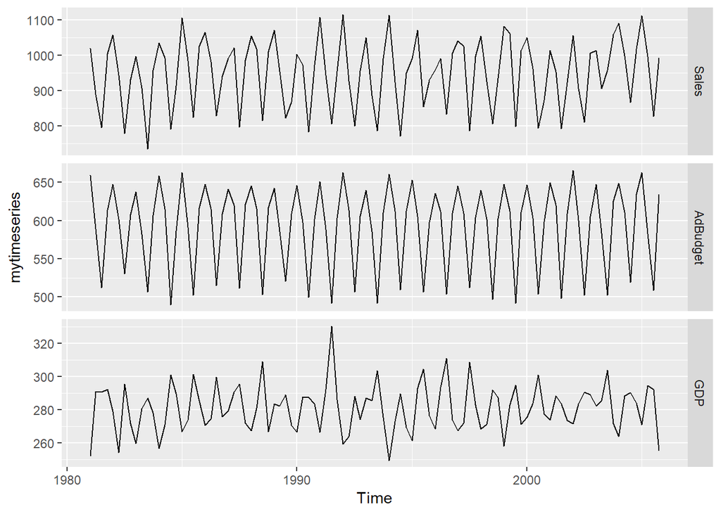

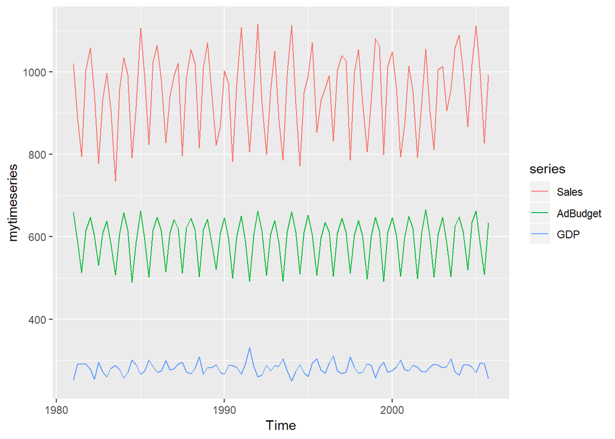

When including facets = T, each of the variables in the time series will be plotted on separate graphs. If the facets = F, then the variables will all be plotted on the same graph in different colors to differentiate them.

### Question 2:

Use the the following graphics functions: `autoplot`, `ggseasonplot`, `ggsubseriesplot`, `gglagplot`, `ggAcf` and explore features from the following time series: `hsales`, `usdeaths`, `bricksq`, `sunspotarea`, `gasoline`.

## hsales

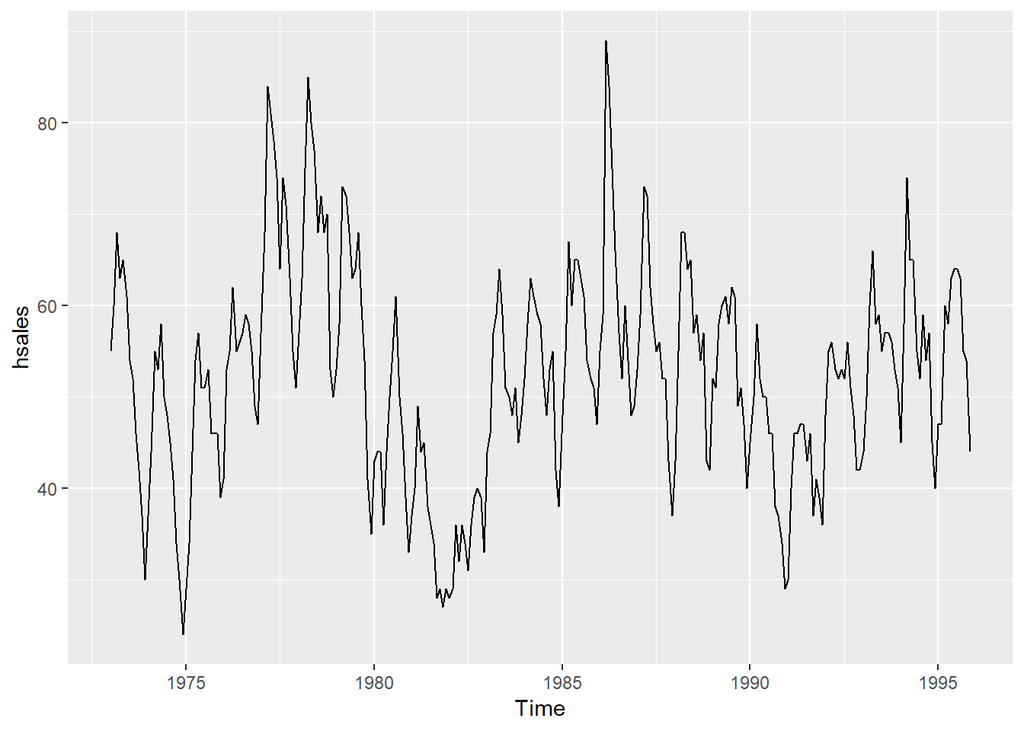

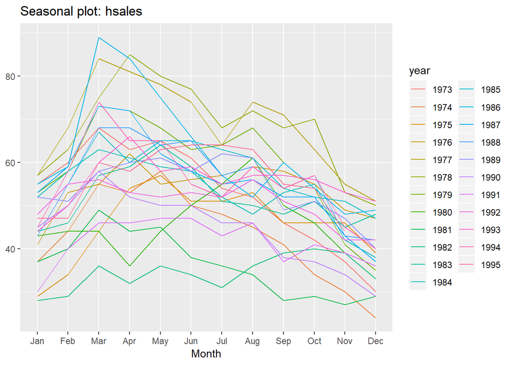

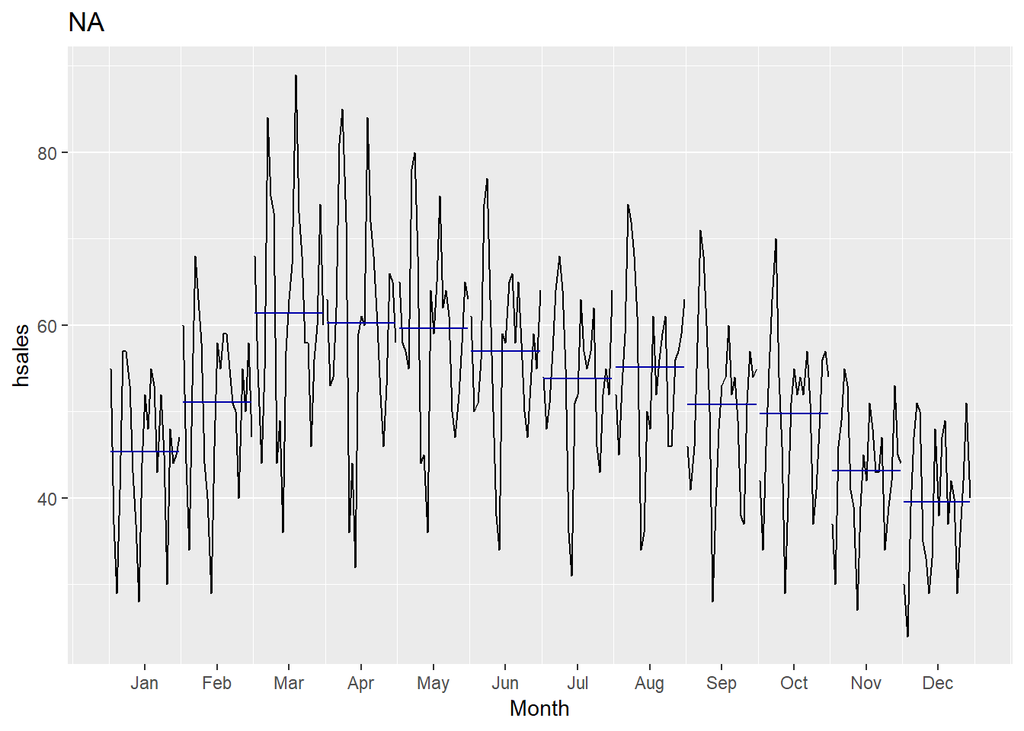

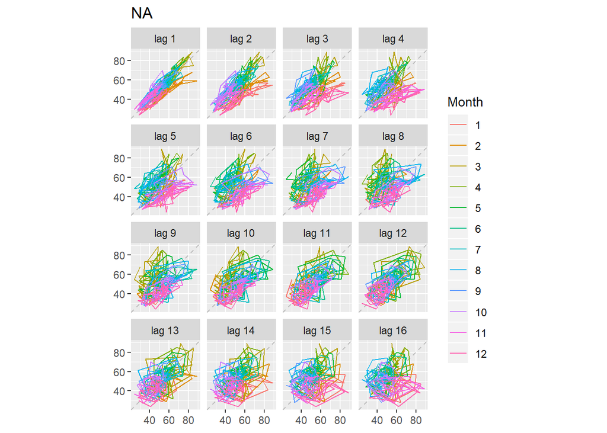

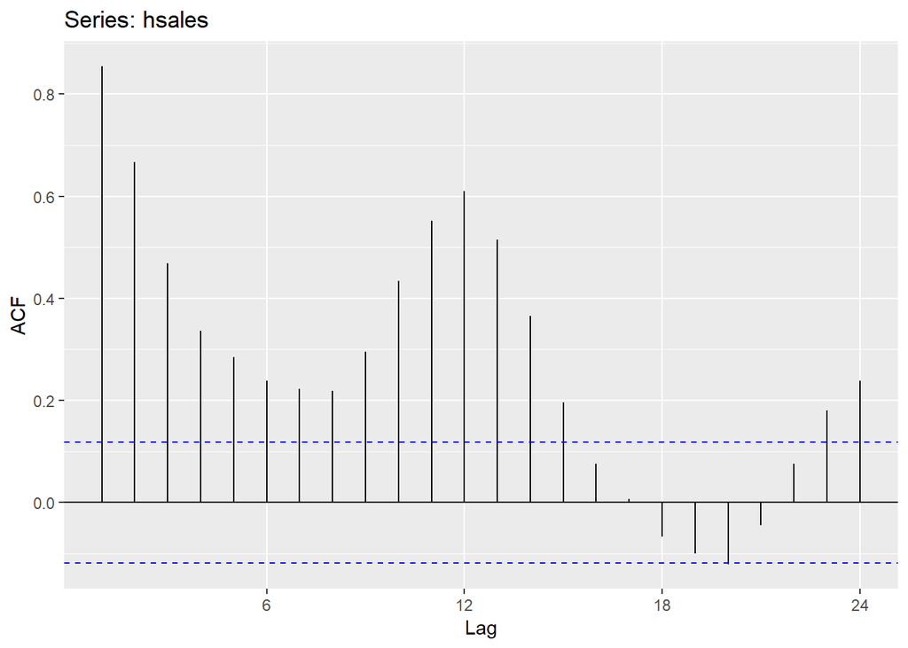

The hsales data seems to have a seasonality to it.

## usdeaths

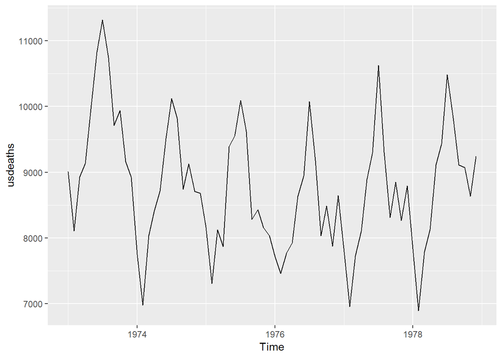

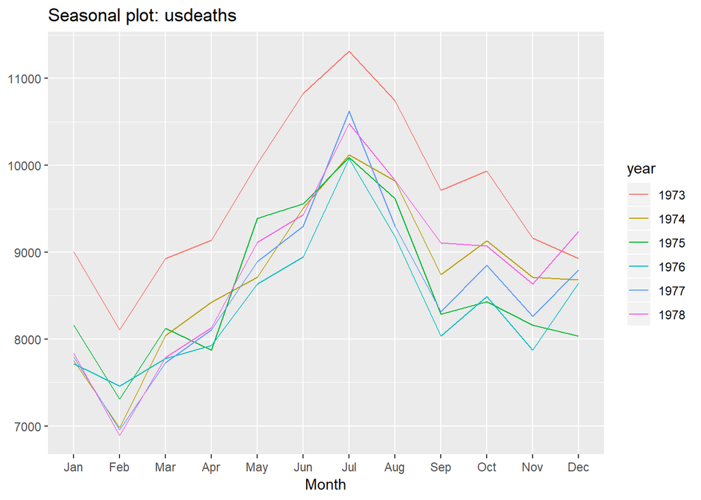

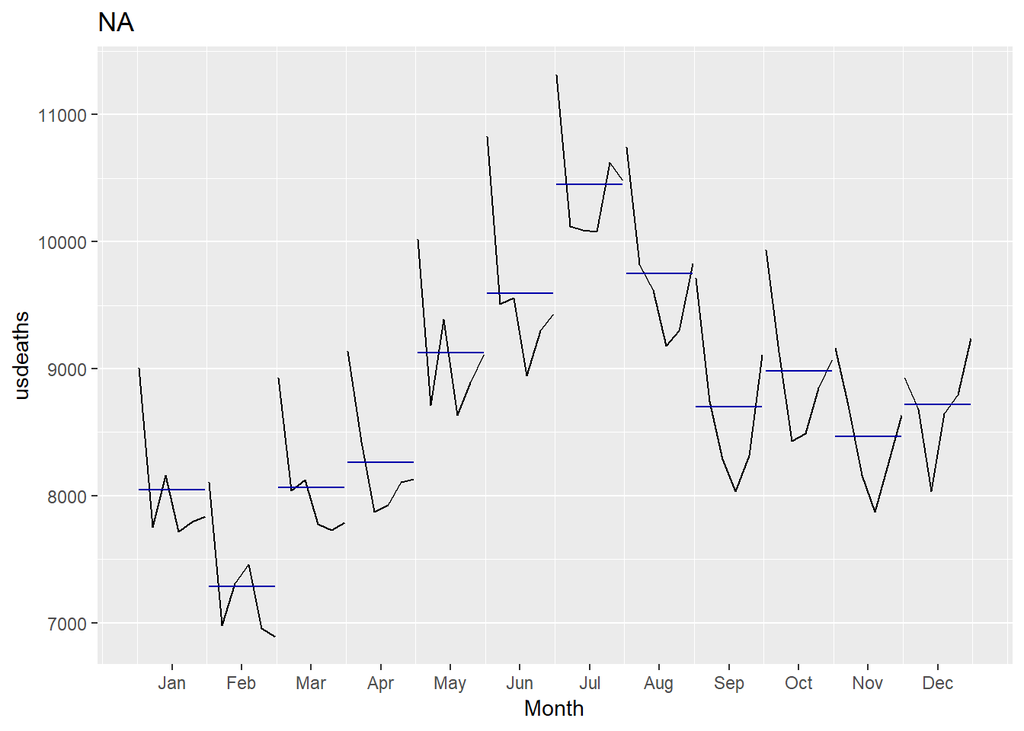

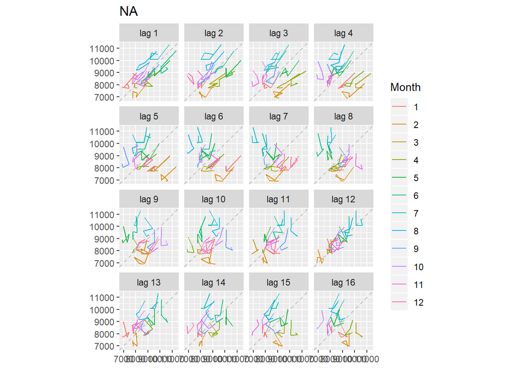

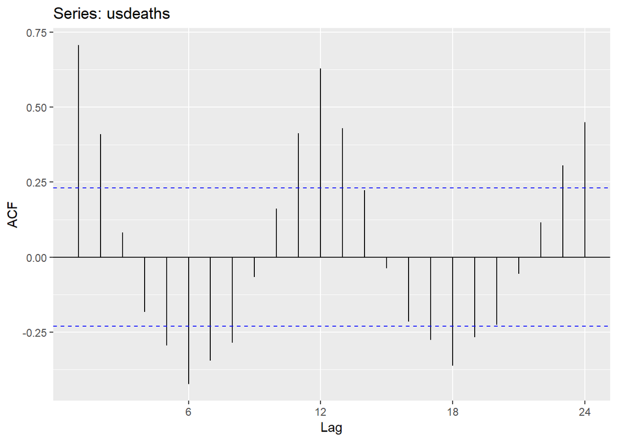

usdeaths definitely has a yearly seasonalit, but no trend of cyclic behavior.

## bricksq

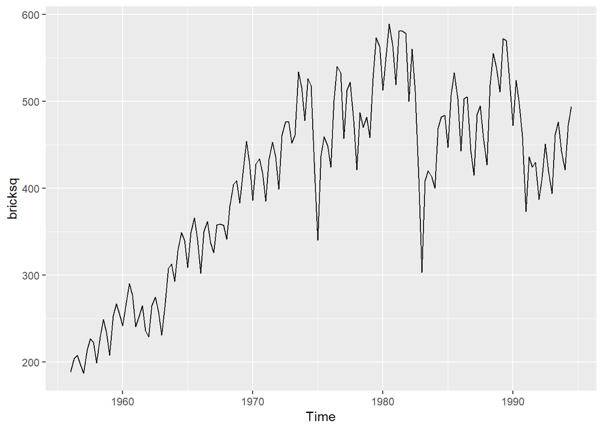

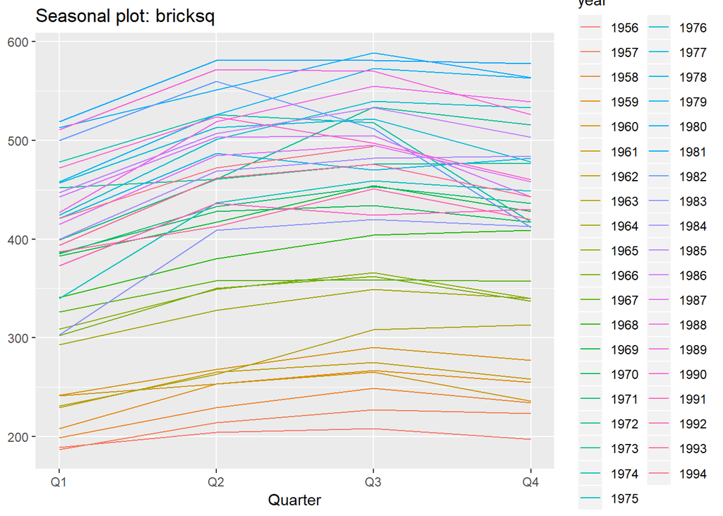

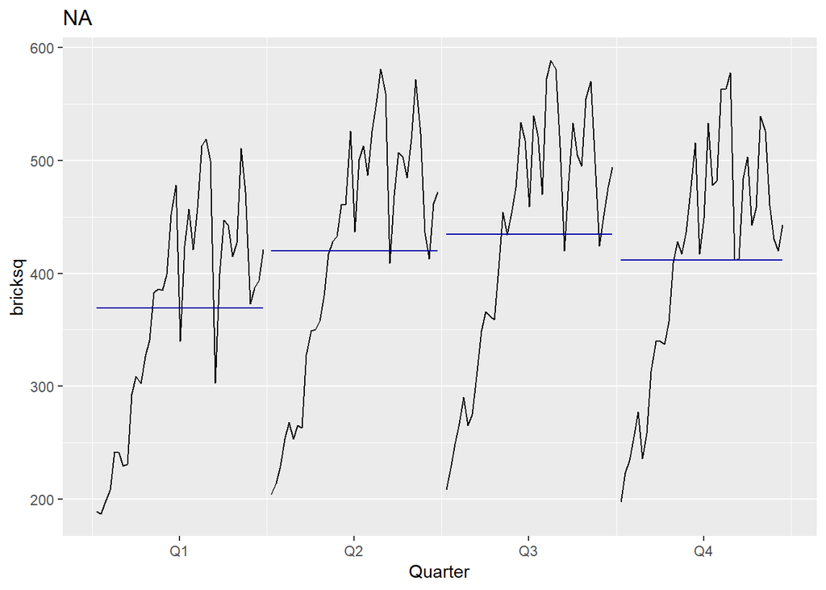

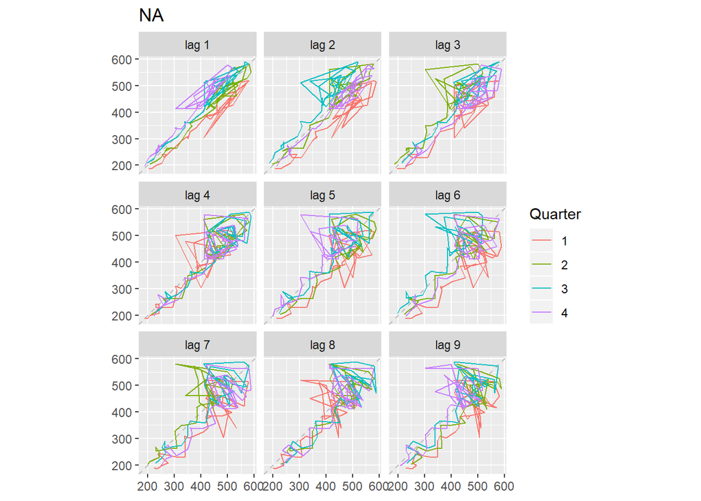

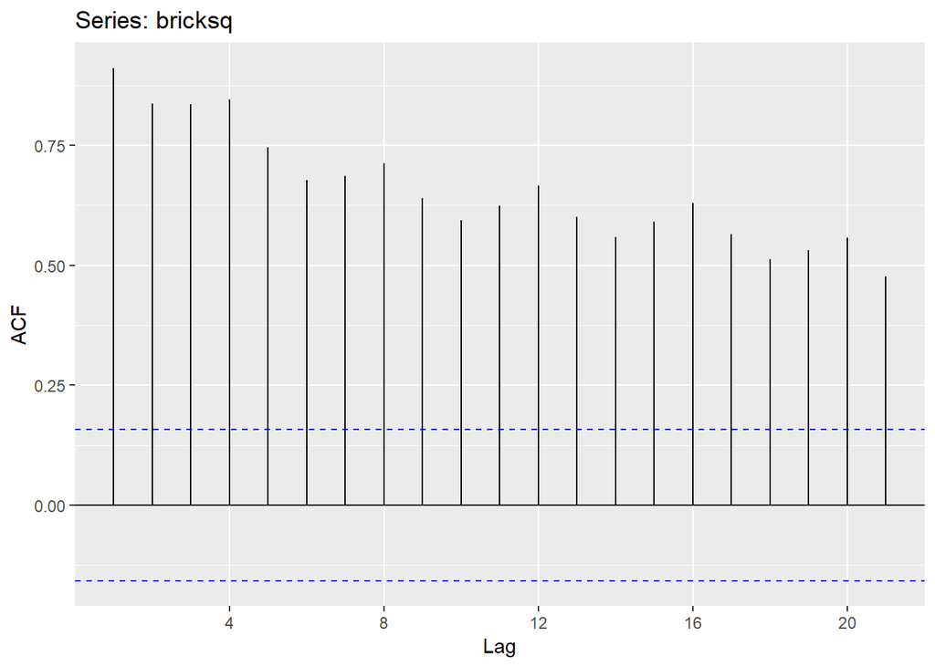

bricksq has a increasing trend with a quarterly seasonality.

## sunspotarea

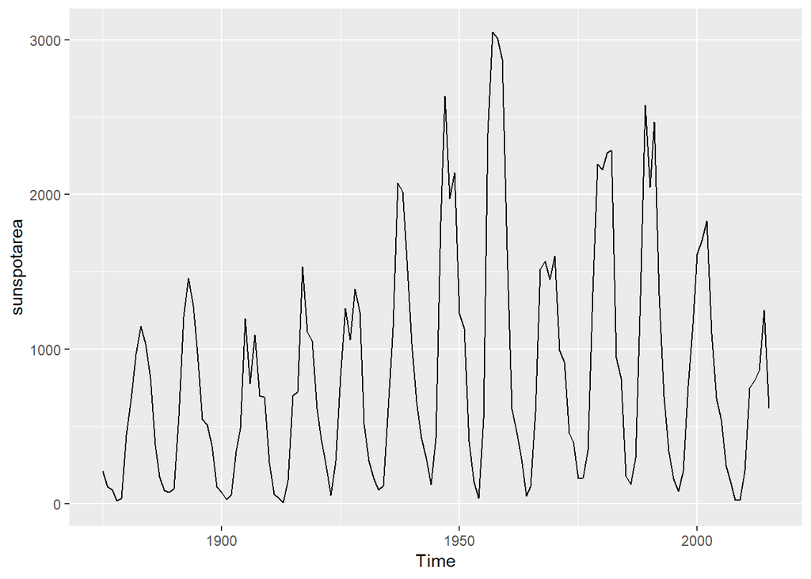

```r
autoplot(sunspotarea)
```

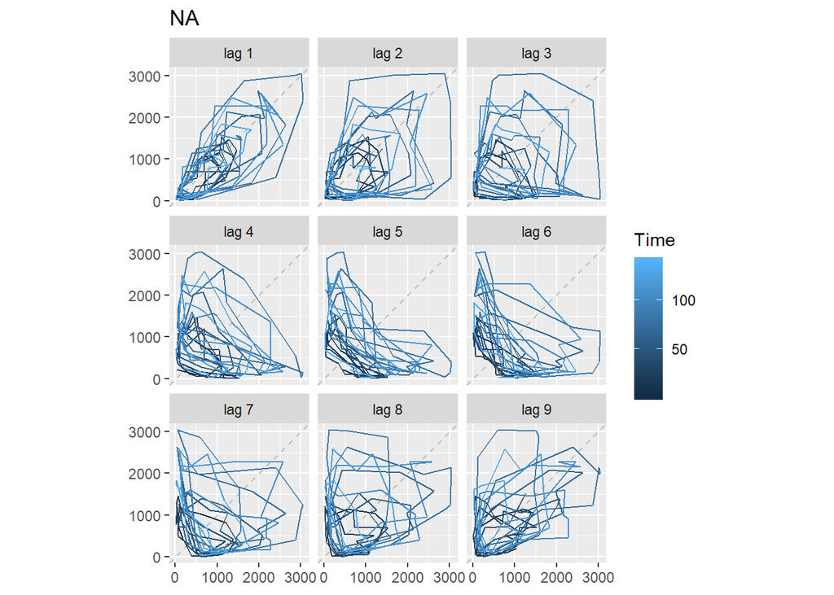

```r
# ggseasonplot(sunspotarea)
# ggsubseriesplot(sunspotarea)
gglagplot(sunspotarea)
```

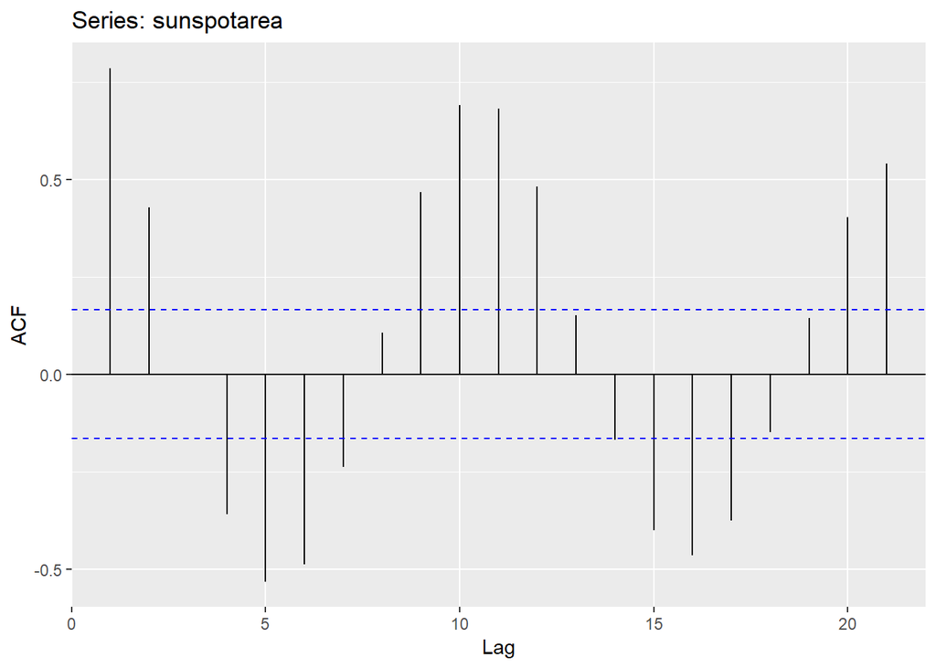

```r
ggAcf(sunspotarea)
```

sunspotarea appears to be cyclical. There were also errors when conducting the `ggseasonalplot` and `ggsubseriesplot` functions because R did not see this dataset having any seasonality.

- For each series, can you spot any seasonality, cyclicity and trend?
- What do you learn about the series?

### Question 3:

`dj` contains 292 consecutive trading days of the Dow Jones Index. Use `ddj <- diff(dj)` to compute the daily changes in the index. Plot `ddj` and its ACF. Do the changes in the Dow Jones Index look like white noise?

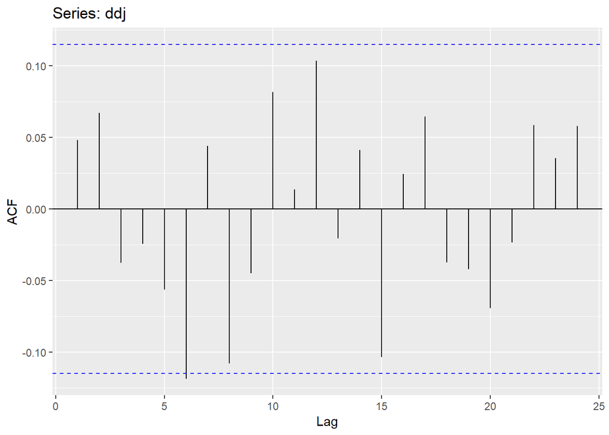

### Question 4:

The `pigs` data shows the monthly total number of pigs slaughtered in Victoria, Australia, from Jan 1980 to Aug 1995. Use `mypigs <- window(pigs, start=1990)` to select the data starting from 1990. Use `autoplot` `Ljung Box test`, and `ggAcf` for `mypigs` series and compare these to white noise plots from Figures `2.15` and `2.16` in the textbook.

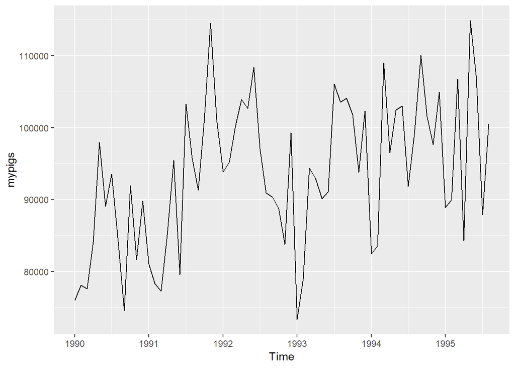

```
##
##  Box-Ljung test
##
## data:  ts(mypigs)
## X-squared = 39.367, df = 20, p-value = 0.006001
```

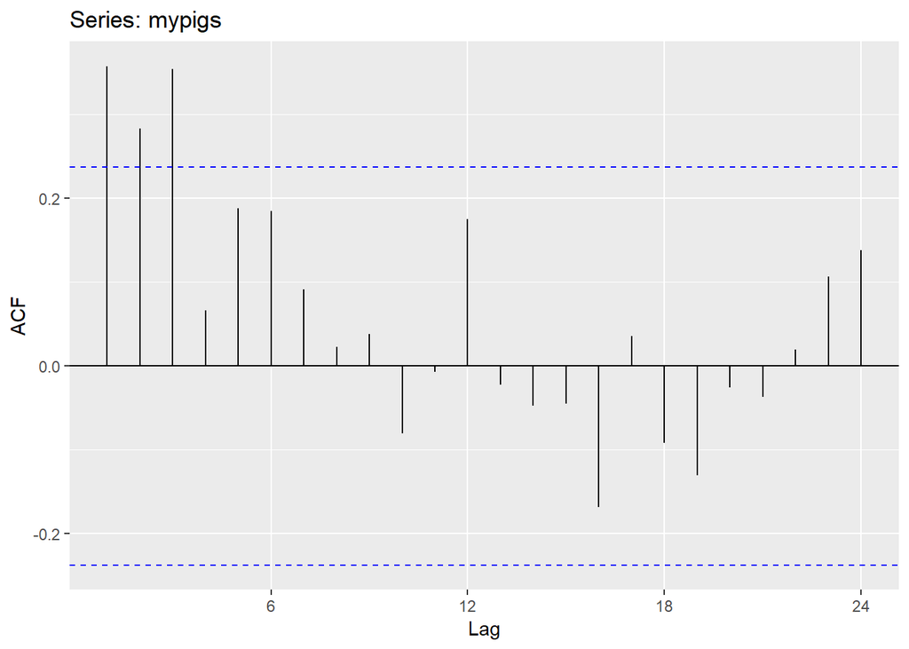